# time how long it takes to repeatedly square them all

### >>>>>`np.ravel()`>>>>>

- is another methods but it direclty converts the array to `1d only`
- ye method zize wagera kuch bhi nhi mangta qk iska kaam hee ye hai ke isko jo bhi matrix mile ussey 1d mai convert kardega, seedha seedha flat kardega jabke `np.reshape()` sai hume kisi bhi dimension mai convert karsakte hain matrix ko
- lekin `np.ravel()` resahpe sirf 1d mai hee karega

```python
# isne seedha seedha 2d array ko 1d mai kardiya

raveled_arr1d = arr2d.ravel()
raveled_arr1d
```

```
array([ 0,  1,  2,  3,  4,  5,  6,  7,  8,  9, 10, 11, 12, 13, 14, 15, 16,
       17, 18, 19, 20, 21, 22, 23, 24, 25, 26, 27, 28, 29, 30, 31, 32, 33,
       34, 35, 36, 37, 38, 39, 40, 41, 42, 43, 44, 45, 46, 47, 48, 49, 50,
       51, 52, 53, 54, 55, 56, 57, 58, 59, 60, 61, 62, 63])
```

### >>>>>>>>`np.ravel()` and `np.reshape()`<<<<<<<<<

- `.reshape()` jab hum karte hain to ye copy nhi banata data ki balke view banata hai
- to original array ki shape change nhi hogi ye naya return karte haain matrix, nayi shape ke andar johumne dee hai
- Even though `.reshape()` and `.ravel()` do not change the shape of the original array or matrix, they do actually return a one-dimensional view into the specified array or matrix. If you change an element in this view, the value in the original array or matrix is changed.
- The following example demonstrates this ability to change items of the original matrix through the view:

```python
# humne arr2d ko ravel kardiya to wo reshape hokar 1d mai convert hogyi
# ab mai ye kar rha hun ke jo raay mai ne ravel ki hai uski 0 index par ye 999 daaldo

raveled_arr1d[0] = 999
raveled_arr1d
```

```
array([999,   1,   2,   3,   4,   5,   6,   7,   8,   9,  10,  11,  12,
        13,  14,  15,  16,  17,  18,  19,  20,  21,  22,  23,  24,  25,
        26,  27,  28,  29,  30,  31,  32,  33,  34,  35,  36,  37,  38,
        39,  40,  41,  42,  43,  44,  45,  46,  47,  48,  49,  50,  51,
        52,  53,  54,  55,  56,  57,  58,  59,  60,  61,  62,  63])
```

```python
# ab mai arr2d ko check karta hun jisko humne reshape kia tha ravel ke through
# to arr2d ko jab mai ne check kia to wo change jo hai wo arr2d mai bhi agya even though mai ne new variable banaya tha
# to ye pata lagi ke ye copy banake alag data nhi rakhta balke ye ussi data ka view change karke dikha rha hota hai, or agar..
# .. view ke andar koi change hoga to original mai bhi change nazar ayega or agar original mai change hoga to view mai bhi..
# .. change nazar ayega, to .revel() or .reshape() dono view banakar dete hain or agar view ke andar ap change karenge to ..
# .. wo original ko bhi hit karega

arr2d   # array shows the effect of change in ravel
```

```
array([[999,   1,   2,   3,   4,   5,   6,   7],
       [  8,   9,  10,  11,  12,  13,  14,  15],
       [ 16,  17,  18,  19,  20,  21,  22,  23],
       [ 24,  25,  26,  27,  28,  29,  30,  31],
       [ 32,  33,  34,  35,  36,  37,  38,  39],
       [ 40,  41,  42,  43,  44,  45,  46,  47],
       [ 48,  49,  50,  51,  52,  53,  54,  55],
       [ 56,  57,  58,  59,  60,  61,  62,  63]])
```

```python
# abhi humne .ravel() ka dekha ab hum .reshape() ka dekhenge
# yahan mai ne 2d array banyi through reshape()
array2d = np.arange(9).reshape(3, 3)
array2d
```

```
array([[0, 1, 2],
       [3, 4, 5],
       [6, 7, 8]])
```

```python
# ab mai yahan isko 1d array banunga dobara
# 1d kese banega maine yahan rows and cols nhi bataye to ye 1d vector banega
# to ye 1 new vector nhi hai balke ussi ka view change karke dikhaya hai isne, yaani matrix wohi hai bas usne apko dikhadiya..
# ..ke apko ye esa dikhega

array1d = array2d.reshape(9)
array1d
```

```
array([0, 1, 2, 3, 4, 5, 6, 7, 8])
```

```python
# ab mai ne kaha ke iske 0 index par 777 daaldo

array1d[0] = 777
array1d
```

```
array([777,   1,   2,   3,   4,   5,   6,   7,   8])
```

```python
# ab mai us original 2darray ko check karta hun jisko reshape kiya tha
# to ye bhi pass by refernce hai

array2d   # show the change done in array1d coz array 1d is view of array2d
```

```
array([[777,   1,   2],
       [  3,   4,   5],
       [  6,   7,   8]])
```

- ye bhi ravel ki tarah seedha array ko 1d mai flat kardega lekin ye copy banaleta hai, ye instead of view copy banaleta hai

### >>>>>np.flatten()>>>>>

- is another methods but it direclty converts the array to 1d only.
- The .flatten() method functions `similarly to .ravel()` but `instead returns a new array with copied data instead of a view`.
- Changes to the result do not change the original matrix:

```python
# ye mai ne 1 array create kari

array = np.arange(25).reshape(5, 5)
array
```

```
array([[ 0,  1,  2,  3,  4],
       [ 5,  6,  7,  8,  9],
       [10, 11, 12, 13, 14],
       [15, 16, 17, 18, 19],
       [20, 21, 22, 23, 24]])
```

```python
# maine kaha array ko faltten kardo

flattened_array = array.flatten()
flattened_array
```

```
array([ 0,  1,  2,  3,  4,  5,  6,  7,  8,  9, 10, 11, 12, 13, 14, 15, 16,
       17, 18, 19, 20, 21, 22, 23, 24])
```

```python
# flattened_array ke index 0 pe 555 daaldo to isne daaldiya

flattened_array[0] = 555
flattened_array
```

```
array([555,   1,   2,   3,   4,   5,   6,   7,   8,   9,  10,  11,  12,
        13,  14,  15,  16,  17,  18,  19,  20,  21,  22,  23,  24])
```

```python
# mai ne kaha ke original array ko check karo, to original array mai change nhi hua
# to .flatten() copy banata hai lekin .ravel() or .reshape() view banate hain

array   # there is no effect in original
```

```
array([[ 0,  1,  2,  3,  4],
       [ 5,  6,  7,  8,  9],
       [10, 11, 12, 13, 14],
       [15, 16, 17, 18, 19],
       [20, 21, 22, 23, 24]])
```

- danger is liye likha hai ke ye original ko reset kardeta hai

# np.resize() Danger!!!!

```python
# mai ne newarray banyi usko reshape kia into 3 by 3
newarray = np.arange(0, 9).reshape(3,3)
newarray
```

```
array([[0, 1, 2],
       [3, 4, 5],
       [6, 7, 8]])
```

```python
# ab mai newarray ko resize kar rha hun r resize ko nex line mai get karna chah  raha hun ke kia hai
# output mai kuch bhi nhi arha jab mai cell execute kar rha hun, to ye keh rha hai ke original ko change kardiya hai jao or..
# jo dekhna hai original mai dekhlo,original mera seedha hogya 3 by 3 tha usne apna kaam wahan pe resize ka kardiya or kuch..
# .. apko return nhi kia

resized = newarray.resize(1, 9)
resized # it is returning none infact it changed the original data
```

```python
newarray
```

```
array([[0, 1, 2, 3, 4, 5, 6, 7, 8]])
```

# Basic Indexing and Slicing of Multidimensional Arrays

```python
# create 2d array
arr2d = np.array([[1, 2, 3], [4, 5, 6], [7, 8, 9]])
arr2d
```

```
array([[1, 2, 3],
       [4, 5, 6],
       [7, 8, 9]])
```

# Indexing:

It is a process in which we target(access)indvidual or group of contagious values of ndarrays.

```python
# accessing a complete row
arr2d[2]
```

```
array([7, 8, 9])
```

```python
# accessing a complete columns
arr2d[:,1]
```

```
array([2, 5, 8])
```

```python
# accessing an element of a 2d array
array2d = np.arange(25).reshape(5,5)
array2d
```

```
array([[ 0,  1,  2,  3,  4],
       [ 5,  6,  7,  8,  9],
       [10, 11, 12, 13, 14],
       [15, 16, 17, 18, 19],
       [20, 21, 22, 23, 24]])
```

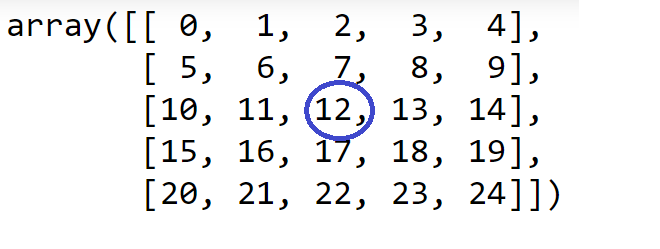

```python
# array2d[2][2]    # isko hum ese bhi likh sakte hain

array2d[2,2] # row number 2 hai or col number bhi 2
```

```
12
```

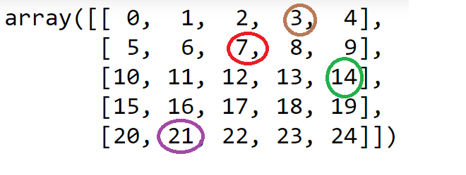

```python
array2d[0,3], array2d[1,2],array2d[2,4],array2d[4,1]
```

```
(3, 7, 14, 21)
```

# Structure for indexing and slicing in a 2darray

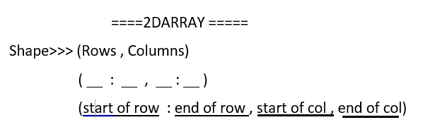

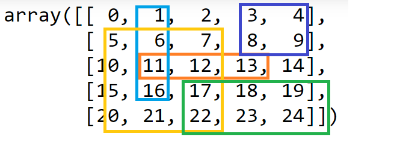

```python
#Light Blue
array2d[0:4, 1:2]
```

```
array([[ 1],
       [ 6],
       [11],
       [16]])
```

```python
#yellow
array2d[1:5, 0:3]
```

```
array([[ 5,  6,  7],
       [10, 11, 12],
       [15, 16, 17],
       [20, 21, 22]])
```

```python
#blue
# array2d[0:2,-2:]
array2d[0:2, 3:]
```

```
array([[3, 4],
       [8, 9]])
```

```python
#green
array2d[3:,2:]
```

```
array([[17, 18, 19],
       [22, 23, 24]])
```

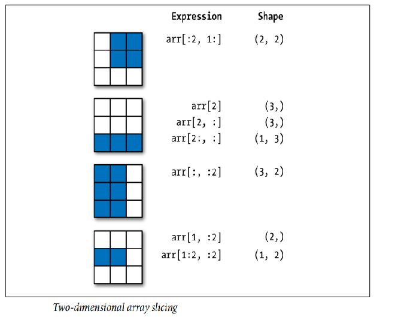